# Analysis of Discrete Traits

## Visualizing our trait

However, even though we may have a good proportion of species in each state it may be that we actually have very few transitions in our dataset and this is really what will be most important to estimating the parameters of the model for the evolution of our traits. For this reason one of the first steps that you should take it to plot your data on your phylogeny and just take a look at the distribution of states across your tree.

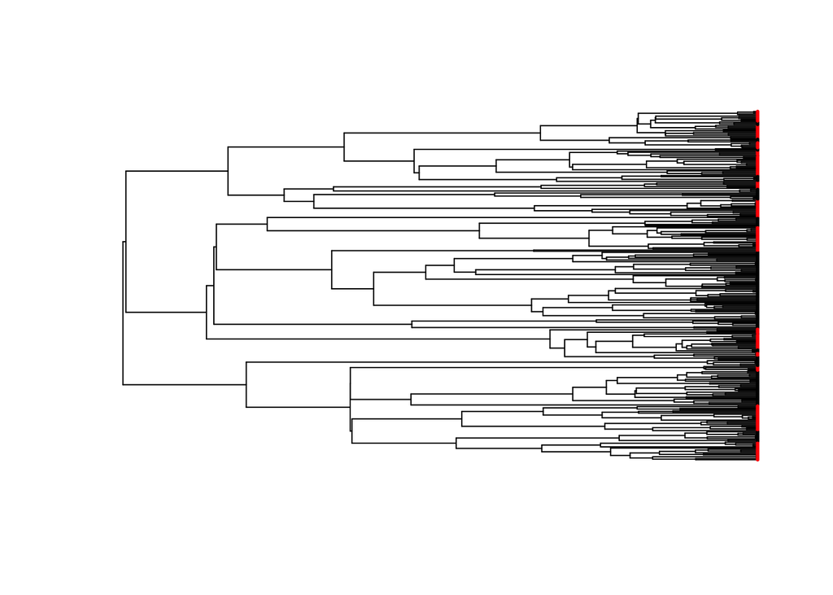

```r
# first lets make a vector of colors that we can use to plot
# symbols at the tip of our tree
cols <- c("red", "black")[scs+1]

# now we plot our tree in this case we are supressing the tips states
plot(phy, show.tip.label = F)

# now we add symbols (pch=16 indicates to use a filled circle)
tiplabels(pch=16, col=cols, cex=.4)
```

## A likelihood function

The first step in analysis of a discrete trait is the creation of a likelihood function. This function calculates the likelihood of our tip data given a phylogeny and values for each of the model parameters.

```r
lik <- make.mk2(tree = phy,
                states = scs)

# now if we supply the likelihood function with a set of parameters it
# will calculate the likelihood of observing the data.

lik(par=c(.2,.2))
```

```
## [1] -64.48608
```

### likelihood values across parameter space

Now that we have a likelihood function we can estimate what parameters do the best job of explaining our data.

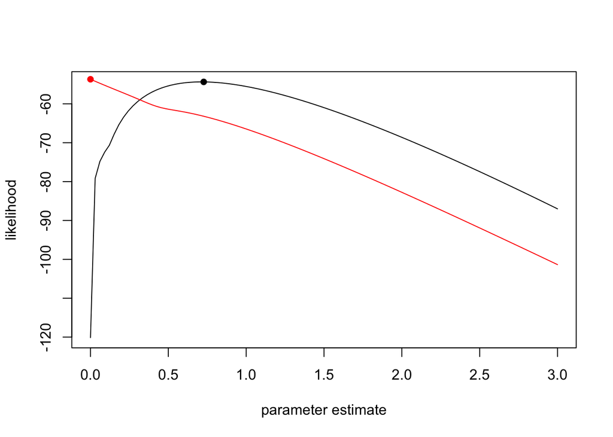

```r
lik1 <- lik2 <- c()
par.vals <- seq(from=0, to = 3, length.out=100)
for(i in par.vals){
  # here we are using the argument root set to ROOT.OBS
  # this will by weighting the probabilities at the root
  # based on the probabilities of the different states at the
  # root
  lik1 <- c(lik1, lik(pars=c(i, .1),
                      root=ROOT.OBS))
}
for(i in par.vals){
  lik2 <- c(lik2, lik(pars=c(.5, i),
                      root=ROOT.OBS))
}
spotq01 <- which.max(lik1)
spotq10 <- which.max(lik2)

plot(y=lik1, x=par.vals, type="l", col="black",
     ylab = "likelihood",
     xlab = "parameter estimate")
lines(y=lik2, x=par.vals, col="red")
points(x=par.vals[spotq01], y=lik1[spotq01], pch=16, col="black")
points(x=par.vals[spotq10], y=lik2[spotq10], pch=16, col="red")
```

## Estimating parameters via maximum likelihood

Now that we have a likelihood functions we can use either a maximum likelihood or Bayesian approach to estimating the values of our parameters.

```r
fit.mle <- find.mle(lik, x.init = runif(min=0, max=1, n=2),
                    root=ROOT.OBS)
fit.mle$par
```

```
##          q01          q10
## 7.030062e-01 2.416782e-08
```

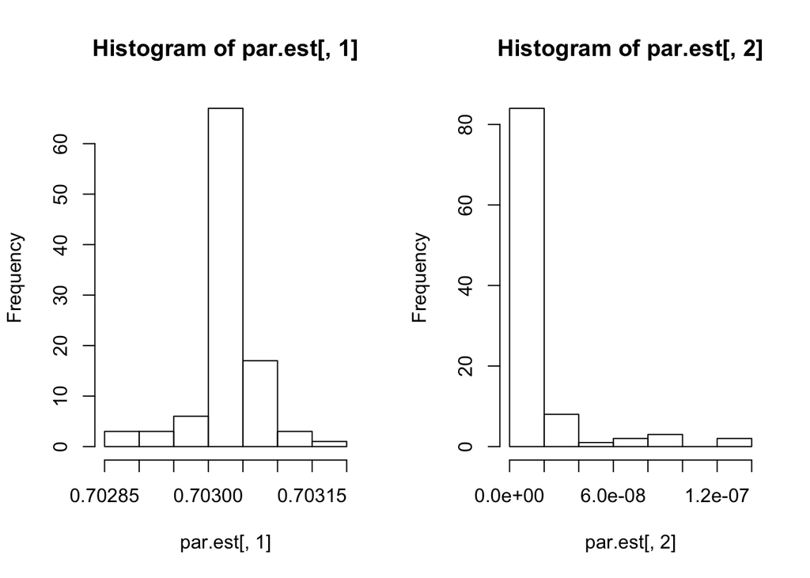

```r
par.est <- matrix(,100,2)
for(i in 1:100){
  init.vals <- runif(min=0, max=1, n=2)
  par.est[i,] <- find.mle(lik, x.init = init.vals)$par
}
par(mfcol=c(1,2))
hist(par.est[,1])
hist(par.est[,2])
```

## Are rates different?

One common question to ask is whether transitions from state 0 to state 1 occur at a different rate than changes from state 1 to state 0. One way that we can do this is by fitting two versions of our model one where these two parameters can be different and another where we constrain them to be equal.

```r
# we have our existing function that allows the parameters to be
# different so we just need to create our version that only has a
# single rate parameter.

con.lik <- constrain(lik, formulae = "q01~q10")
fit.mle2 <- find.mle(con.lik, x.init = init.vals[1])
anova(fit.mle, fit.mle2)
```

```
##         Df   lnLik    AIC ChiSq Pr(>|Chi|)
## full     2 -52.724 109.45
## model 1  1 -61.089 124.18 16.73   4.31e-05 ***
## ---
## Signif. codes:  0 '***' 0.001 '**' 0.01 '*' 0.05 '.' 0.1 ' ' 1
```

## Estimating parameters via Bayesian

We can use this same likelihood function to estimate our parameters in a Bayesian framework.

```r
fit.mcmc <- diversitree::mcmc(lik, x.init = init.vals,
                              nsteps = 3000, w = 1,
                              print.every = 250)
```

```
## 250: {0.8200, 0.0194} -> -53.26424
## 500: {0.6989, 0.0602} -> -53.71054
## 750: {0.7559, 0.0784} -> -54.03899
## 1000: {0.5235, 0.0064} -> -53.56069
## 1250: {0.8769, 0.2436} -> -56.98045
## 1500: {0.6872, 0.0891} -> -54.18923
## 1750: {0.5836, 0.0971} -> -54.64891
## 2000: {0.6093, 0.0430} -> -53.62467
## 2250: {0.4780, 0.0138} -> -54.17267
## 2500: {0.6770, 0.0073} -> -52.85752
## 2750: {0.9588, 0.0089} -> -53.85007
## 3000: {0.6610, 0.0133} -> -52.98006
```

```r
library(coda)
```

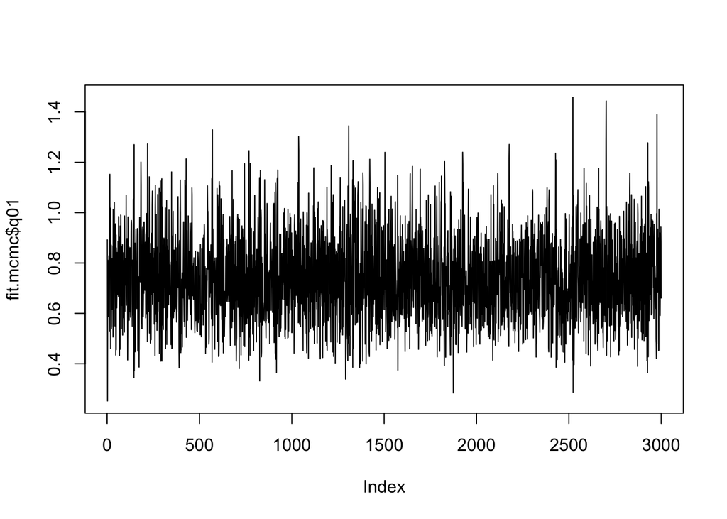

```r
plot(fit.mcmc$q01, type = "l")
```

```r
post.burnin <- fit.mcmc[101:3000,]
HPDinterval(as.mcmc(post.burnin))
```

```
##             lower        upper
## i    1.010000e+02 2856.0000000
## q01  4.258539e-01    1.0785879
## q10  9.189914e-06    0.1913504
## p   -5.675683e+01  -52.7391820
## attr(,"Probability")
## [1] 0.95
```

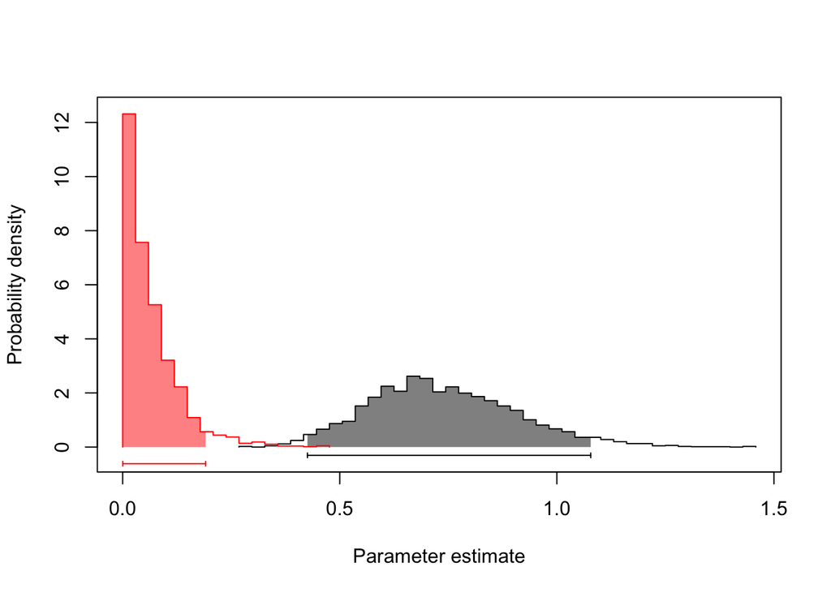

```r
profiles.plot(post.burnin[,2:3], col.line = c("black", "red"))
```

In the example above you might have noticed that I don’t initially provide any type of prior. In diversitree this means that we are actually specifying a uniform prior. For some analyses this might be OK we might not have any strong prior information that informs what we believe the rates should be. However, in many empirical data sets this can lead to problems where the MCMC starts to explore biologically unrealistic rates of evolution that are far too high. To deal with this we might want to apply a relatively uninformative prior that will keep rates in a reasonable range.

```r
prior <- make.prior.exponential(1)
fit.mcmc.wprior <- diversitree::mcmc(lik, x.init = init.vals,
                              nsteps = 3000, w = 1,
                              print.every = 250,
                              prior = prior)
```

```
## 250: {1.0783, 0.0096} -> -55.91750
## 500: {0.6240, 0.2566} -> -57.91833
## 750: {0.7581, 0.0168} -> -53.82424
## 1000: {0.6004, 0.0347} -> -54.16004
## 1250: {0.7043, 0.0077} -> -53.56196
## 1500: {0.8047, 0.0662} -> -54.82727
## 1750: {0.7602, 0.0358} -> -54.15725
## 2000: {0.8340, 0.0457} -> -54.61392
## 2250: {0.6922, 0.0145} -> -53.67194
## 2500: {0.6019, 0.1727} -> -56.56062
## 2750: {1.0093, 0.0105} -> -55.27189
## 3000: {0.7612, 0.0235} -> -53.94917
```

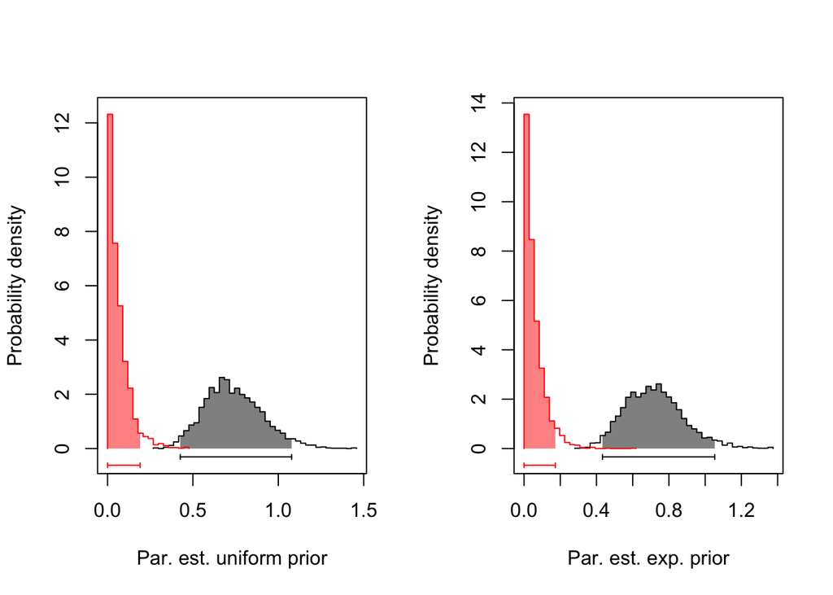

```r
par(mfcol=c(1,2))
post.burnin.wprior <- fit.mcmc.wprior[101:3000,]
profiles.plot(post.burnin[,2:3], col.line = c("black", "red"),
              xlab="Par. est. uniform prior")
profiles.plot(post.burnin.wprior[,2:3], col.line = c("black", "red"),
              xlab="Par. est. exp. prior")
```

When we look at the posterior distribution for these two parameters what we see is that the use of a broad somewhat informative prior vs a uniform prior has little impact on the posterior distribution of our rate estimates. This suggests that our data is quite informative. This isn’t too suprising since we simulated quite a large dataset with many transitions.

This is a pretty simple model and the MCMC runs quite well. Even with trait models that have relatively few parameters you can run into situations where the MCMC doesn’t work well. Here is an [example](http://coleoguy.github.io/bad.mcmc.pdf) of this with a model looking at rates of chromosome evolution. What we see here is that there are two areas of parameter space that do a fairly equally good job of explaining our observed data. Because of this our simple MCMC algorithm tended to get stuck in one of these local optimums. How we interpret something like this may be somewhat dependent on the model that we are fitting but in this particular example our model was attempting to identify which state in our binary character was associated with differences in rates of evolution and positive and negative values for the statistic were telling us which state is associated with increased rates. Therefor I interpreted this result as suggestive that the binary character that we were studying does a poor job of predicting variation in rates of chromosome evolution

## Stochastic mapping

Stochastic mapping is an approach to visualize one possible evolutionary history for your trait. I won’t go into great depth on the method but the briefly what is done is to first fix an ancestral state for every internal node in the tree and then starting at the root reconstruct a history on each branch of the phylogeny. Stochastic mapping can be slow because it uses rejection sampling. For instance, as we work our way through the tree we reject simulations that are not in the state already selected for the end state of the branch. This is mainly a problem when we have a trait with many states.

```r
library(phytools)
```

```r
map <- make.simmap(tree=phy, x=scs, model="ARD",
                   pi="estimated")
```

[output not shown]

```
## Done.
```

```
## no colors provided. using the following legend:
##       0       1
## "black"   "red"
```

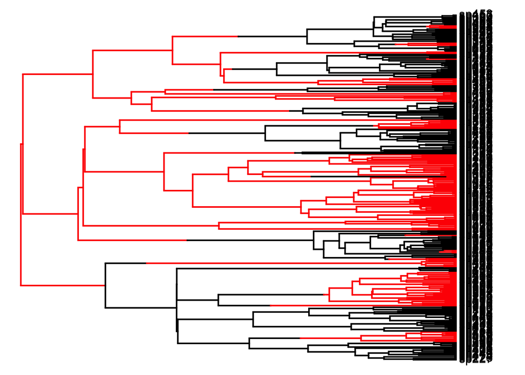

```r
plotSimmap(map)
```

```r
countSimmap(map)
```

```
## $N
## [1] 22
##
## $Tr
##   0  1
## 0 0 13
## 1 9  0
##
## $message
## [1] "N is the total number of character changes on the tree"
## [2] "Tr gives the number of transitions from row state->column state"
```

Because stochastic maps represent possible evolutionary histories for our discrete trait they can be a powerful tools to use in other analyses for instance we might ask if a continuous trait evolves at different rate on branches that are reconstructed to be in state one vs two. Another use of stochastic maps is just as a sanity check on our rate parameters. As an example lets purposely get our trait data out of order and do our stochastic mapping to see what it might look like if we have unrealistically high rates of evolution

```r
# create a copy of the observed data
scs.new <- scs

set.seed(2)

# shuffle 200 of our datapoints
scs.new[c(1:200)] <- sample(0:1, 200, replace=T)

# generate a possible history for our trait
map <- make.simmap(tree=phy, x=scs.new, model="ARD", pi="estimated")
```

```
## Using pi estimated from the stationary distribution of Q assuming a flat prior.
## pi =
##        0        1
## 0.538853 0.461147
##
## make.simmap is sampling character histories conditioned on the transition matrix
##
## Q =
##           0         1
## 0 -6.879288  6.879288
## 1  8.038473 -8.038473
## (estimated using likelihood);
## and (mean) root node prior probabilities
## pi =
##         0         1
## 0.5388525 0.4611475
```

```
## Done.
```

```
## no colors provided. using the following legend:
##       0       1
## "black"   "red"
```

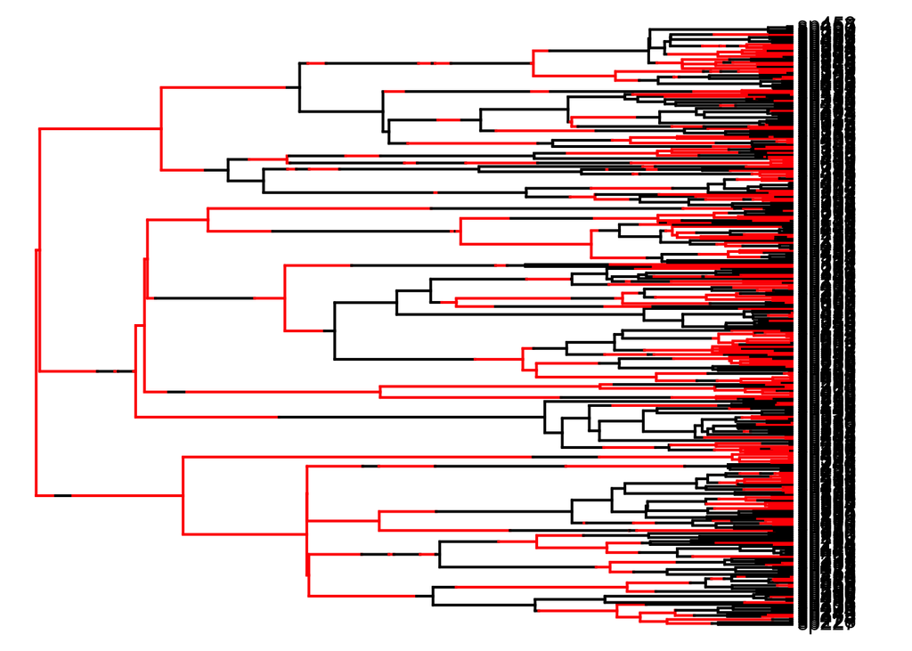

```r
plotSimmap(map)
```

```r
countSimmap(map)
```

```
## $N
## [1] 340
##
## $Tr
##     0   1
## 0   0 180
## 1 160   0
##
## $message
## [1] "N is the total number of character changes on the tree"
## [2] "Tr gives the number of transitions from row state->column state"
```